# Scraping data from Twitter

Pablo Barbera

March, 2016

### Scraping web data from Twitter

#### Authenticating

Follow these steps to create your token:

1. Go to apps.twitter.com and sign in.
2. Click on “Create New App”. You will need to have a phone number associated with your account in order to be able to create a token.
3. Fill name, description, and website (it can be anything, even http://www.google.com). Make sure you leave ‘Callback URL’ empty.
4. Agree to user conditions.
5. From the “Keys and Access Tokens” tab, copy consumer key and consumer secret and paste below

```r
# install.packages("ROAuth")
library(ROAuth)
requestURL <- "https://api.twitter.com/oauth/request_token"
accessURL <- "https://api.twitter.com/oauth/access_token"
authURL <- "https://api.twitter.com/oauth/authorize"
consumerKey <- "XXXXXXXXXXXX"
consumerSecret <- "YYYYYYYYYYYYYYYYYYY"

my_oauth <- OAuthFactory$new(consumerKey=consumerKey,
  consumerSecret=consumerSecret, requestURL=requestURL,
  accessURL=accessURL, authURL=authURL)
```

Run the below line and go to the URL that appears on screen. Then, type the PIN into the console (RStudio sometimes doesn’t show what you’re typing, but it’s there!)

```r
my_oauth$handshake(cainfo = system.file("CurlSSL", "cacert.pem", package = "RCurl"))
```

Now you can save oauth token for use in future sessions with smappR or streamR. Make sure you save it in a folder where this is the only file.

```r
save(my_oauth, file="~/git/icours-workshop/02-social-media/credentials/twitter-token.Rdata")
```

#### Collecting data from Twitter’s Streaming API

Collecting tweets filtering by keyword:

```r
#install.packages("streamR")
library(streamR)
load("~/git/icourts-workshop/02-social-media/credentials/twitter-token.Rdata")
filterStream(file.name="brexit-tweets.json", track="#brexit",
    timeout=30, oauth=my_oauth)
```

```
## Capturing tweets...
## Connection to Twitter stream was closed after 30 seconds with up to 20 tweets downloaded.
```

Note the options: - `file.name` indicates the file in your disk where the tweets will be downloaded  
- `track` is the keyword(s) mentioned in the tweets we want to capture. - `timeout` is the number of seconds that the connection will remain open  
- `oauth` is the OAuth token we are using

Once it has finished, we can open it in R as a data frame with the `parseTweets` function

```r
tweets <- parseTweets("brexit-tweets.json")
```

```
## 11 tweets have been parsed.
```

```r
str(tweets)
```

```
## 'data.frame':    11 obs. of  42 variables:
##  $ text                     : chr  "@StrongerIn Oh dear @NickyMorgan01 isn't a very good role model for young ppl is she!! Teaching them to LIE in order to get own"| __truncated__ "RT @MdDeactivated: Clearly many businesses are not pro - EU and don't advocate staying in . . .They're the one's who…
##  $ retweet_count            : num  0 7 0 0 3 0 0 0 10 0 ...
##  $ favorited                : logi  FALSE FALSE FALSE FALSE FALSE FALSE ...
##  $ truncated                : logi  FALSE FALSE FALSE FALSE FALSE FALSE ...
##  $ id_str                   : chr  "714852129601679361" "714852136207663105" "714852144990433280" "714852148752859137" ...
##  $ in_reply_to_screen_name  : chr  "StrongerIn" NA NA NA ...
##  $ source                   : chr  "<a href=\"http://twitter.com/download/android\" rel=\"nofollow\">Twitter for Android</a>" "<a href=\"http://twitter.com\" rel=\"nofollow\">Twitter Web Client</a>" "<a href=\"http://www.radiofreeuk.org\" rel=\"nofollow\">RFreeUK_Listen</a>" "<a href=\"http://twi…
##  $ retweeted                : logi  FALSE FALSE FALSE FALSE FALSE FALSE ...
##  $ created_at               : chr  "Tue Mar 29 16:30:03 +0000 2016" "Tue Mar 29 16:30:05 +0000 2016" "Tue Mar 29 16:30:07 +0000 2016" "Tue Mar 29 16:30:08 +0000 2016" ...
##  $ in_reply_to_status_id_str: chr  "714835563208175616" NA NA NA ...
##  $ in_reply_to_user_id_str  : chr  "3342929843" NA NA NA ...
##  $ lang                     : chr  "en" "en" "en" "en" ...
##  $ listed_count             : num  69 1 8 75 558 77 111 2 6 5 ...
##  $ verified                 : logi  FALSE FALSE FALSE FALSE FALSE FALSE ...
```

[output cut: 28 more lines]

```r
tweets[1,]
```

```
##                                                                                                                                           text
## 1 @StrongerIn Oh dear @NickyMorgan01 isn't a very good role model for young ppl is she!! Teaching them to LIE in order to get own way! #Brexit
##   retweet_count favorited truncated             id_str
## 1             0     FALSE     FALSE 714852129601679361
##   in_reply_to_screen_name
## 1              StrongerIn
##                                                                                 source
## 1 <a href="http://twitter.com/download/android" rel="nofollow">Twitter for Android</a>
##   retweeted                     created_at in_reply_to_status_id_str
## 1     FALSE Tue Mar 29 16:30:03 +0000 2016        714835563208175616
##   in_reply_to_user_id_str lang listed_count verified
## 1              3342929843   en           69    FALSE
##                  location user_id_str
## 1 England, United Kingdom   167867162
##                                                                                                    description
## 1 Anti-EU ,#BREXIT,\nAnti-Incineration,\nAnti-Heathrow expansion,\nWest Ham United #COYI,\nAtheist, #BinTheBBC
##   geo_enabled                user_created_at statuses_count
## 1       FALSE Sat Jul 17 18:43:01 +0000 2010          29336
##   followers_count favourites_count protected user_url               name
## 1             692            25655     FALSE     <NA> Hammertime #Brexit
##   time_zone user_lang utc_offset friends_count   screen_name country_code
## 1      <NA>        en         NA           527 Hammertime983         <NA>
##   country place_type full_name place_name place_id place_lat place_lon lat
## 1    <NA>       <NA>      <NA>         NA       NA       NaN       NaN  NA
##   lon expanded_url  url
## 1  NA         <NA> <NA>
```

If we want, we could also export it to a csv file to be opened later with Excel

```r
write.csv(tweets, file="brexit-tweets.csv", row.names=FALSE)
```

And this is how we would capture tweets mentioning multiple keywords:

```r
filterStream(file.name="uk-tweets.json",
    track=c("#brexit", "#LeaveEU", "#StrongerIn", "#VoteLeave", "#EU", "#EURef",
            "referendum"),
    tweets=30, oauth=my_oauth)
```

Note that here I choose a different option, `tweets`, which indicates how many tweets (approximately) the function should capture before we close the connection to the Twitter API.

This second example shows how to collect tweets filtering by location instead. In other words, we can set a geographical box and collect only the tweets that are coming from that area.

In the case of Denmark, it would be approx. (7.4, 54.3) and (14.8, 57.7). How to find these coordinates? I use: `http://itouchmap.com/latlong.html`

```r
filterStream(file.name="tweets_geo.json", locations=c(7.4, 54.3, 14.8, 57.7),
    timeout=1800, oauth=my_oauth)
```

We can do as before and open the tweets in R

```r
tweets <- parseTweets("../tweets_geo.json")
```

```
## 346 tweets have been parsed.
```

And use the maps library to see where most tweets are coming from. Note that there are two types of geographic information on tweets: `lat`/`lon` (from geolocated tweets) and `place_lat` and `place_lon` (from tweets with place information). We will work with whatever is available.

```r
library(maps)
library(mapdata)
tweets$lat <- ifelse(is.na(tweets$lat), tweets$place_lat, tweets$lat)
tweets$lon <- ifelse(is.na(tweets$lon), tweets$place_lon, tweets$lon)
countries <- map.where("worldHires", tweets$lon, tweets$lat)
head(sort(table(countries), decreasing=TRUE))
```

```
## countries
##            Sweden Denmark:Sjaelland           Denmark            Poland
##               104                87                31                31
##           Germany       Denmark:Fyn
##                21                12
```

We can also prepare a map of the exact locations of the tweets.

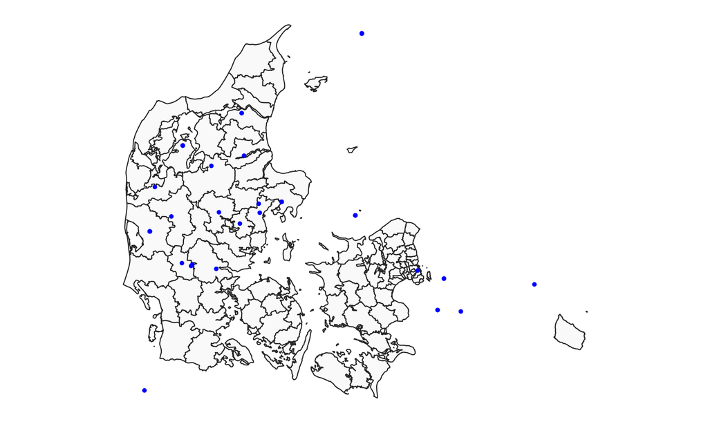

```r
# subset only tweets in Denmark
tweets <- tweets[countries=="Denmark" | is.na(countries),]

#if(!require("devtools")) install.packages("devtools")
#devtools::install_github("sebastianbarfort/mapDK")
library(mapDK)
pointDK(tweets, point.colour="blue", map.fill="gray98", map.colour="grey20")
```

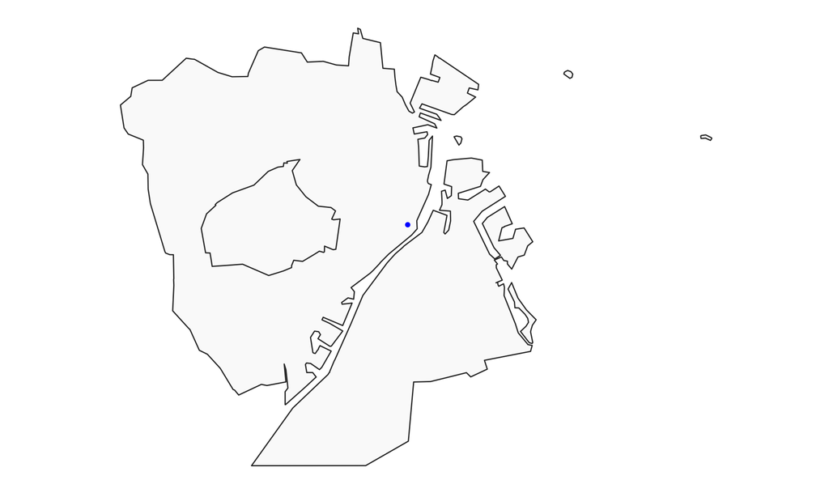

```r
# and only tweets in Copenhagen
cph <- tweets[tweets$lat > 55 & tweets$lat<56 & tweets$lon>12 & tweets$lon<12.7,]
pointDK(cph, sub = "koebenhavn", point.colour="blue", map.fill="gray98", map.colour="grey20")
```

Finally, it’s also possible to collect a random sample of tweets. That’s what the “sampleStream” function does:

```r
sampleStream(file.name="tweets_random.json", timeout=30, oauth=my_oauth)
```

```
## Capturing tweets...
## Connection to Twitter stream was closed after 30 seconds with up to 3561 tweets downloaded.
```

Here I’m collecting 30 seconds of tweets. And once again, to open the tweets in R…

```r
tweets <- parseTweets("tweets_random.json")
```

```
## 1533 tweets have been parsed.
```

What is the most retweeted tweet?

```r
tweets[which.max(tweets$retweet_count),]
```

```
##                                   text retweet_count favorited truncated
## 1190 RT @Harry_Styles: Love everybody.        333235     FALSE     FALSE
##                  id_str in_reply_to_screen_name
## 1190 714852351895535616                    <NA>
##                                                                             source
## 1190 <a href="http://www.twitter.com" rel="nofollow">Twitter for Windows Phone</a>
##      retweeted                     created_at in_reply_to_status_id_str
## 1190     FALSE Tue Mar 29 16:30:56 +0000 2016                      <NA>
##      in_reply_to_user_id_str lang listed_count verified location
## 1190                    <NA>   en            2    FALSE  na sua
##      user_id_str
## 1190  4563400343
##                                                                                           description
## 1190 eclectic // my heart is hipster and cliché at the same time \u2b50 cashton ♡ larry ♡ muke ♡ ziam
##      geo_enabled                user_created_at statuses_count
## 1190       FALSE Tue Dec 22 02:59:37 +0000 2015            666
##      followers_count favourites_count protected user_url
## 1190              76             1024     FALSE     <NA>
##                      name time_zone user_lang utc_offset friends_count
## 1190 MIND OF MINEEEEEEEEE      <NA>        en         NA           262
##      screen_name country_code country place_type full_name place_name
## 1190    kitvarao         <NA>    <NA>       <NA>      <NA>         NA
##      place_id place_lat place_lon lat lon expanded_url  url
## 1190       NA       NaN       NaN  NA  NA         <NA> <NA>
```

What are the most popular hashtags at the moment? We’ll use regular expressions to extract hashtags.

```r
library(stringr)
ht <- str_extract_all(tweets$text, "#(\\d|\\w)+")
ht <- unlist(ht)
head(sort(table(ht), decreasing = TRUE))
```

```
## ht
## #iHeartAwards  #BestFanArmy  #Harmonizers         #GOT7  #gameinsight
##            19            16             9             8             7
##      #android
##             5
```

How many tweets mention Justin Bieber?

```r
length(grep("bieber", tweets$text, ignore.case=TRUE))
```

```
## [1] 3
```

#### Collecting data from Twitter’s REST API

It is possible to download recent tweets, but only up those less than 7 days old, and in some cases not all of them. We will use the `smappR` package for this (and the other functions that scrape Twitter’s REST API).

```r
#install.packages("devtools")
library(devtools)
#install_github("SMAPPNYU/smappR")
library(smappR)
searchTweets(q=c("karadžić", "karadzic", "Караџић"),
  filename="karadzic-tweets.json",
  n=1000, until="2016-03-25",
  oauth_folder="~/git/icourts-workshop/02-social-media/credentials")
```

```
## 100 tweets. Max id: 713153355342807040
## 178 hits left
## 200 tweets. Max id: 713149435509923840
## 177 hits left
## 300 tweets. Max id: 713146356852916224
## 176 hits left
## 400 tweets. Max id: 713144070357389312
## 175 hits left
## 500 tweets. Max id: 713139282911821824
## 174 hits left
## 600 tweets. Max id: 713132396011458560
## 173 hits left
## 700 tweets. Max id: 713126689874685952
## 172 hits left
## 800 tweets. Max id: 713121156488949760
## 171 hits left
## 900 tweets. Max id: 713116580675235840
## 170 hits left
## 1000 tweets. Max id: 713112670724091904
```

```r
tweets <- parseTweets("karadzic-tweets.json")
```

```
## 1000 tweets have been parsed.
```

What are the most popular hashtags?

```r
library(stringr)
ht <- str_extract_all(tweets$text, "#(\\d|\\w)+")
ht <- unlist(ht)
head(sort(table(ht), decreasing = TRUE))
```

```
## ht
##      #Karadžić      #genocide          #ICTY    #Srebrenica         #Bemba
##            196             40             39             38              9
## #GlobalJustice
##              9
```

You can check the documentation about the options for string search [here](https://dev.twitter.com/rest/public/search).

This is how you would extract information from user profiles:

```r
ics <- c("IntlCrimCourt", "ICJ_org", "CorteIDH", "CIDH", "ComunidadAndina",
         "ECHR_Press", "ICTYnews", "SpecialCourt", "EACJCourt",
         "EUCourtPress", "CourUEPresse", "TPRMERCOSUR", "afchpr")
users <- getUsersBatch(screen_names=ics,
                       oauth_folder="~/git/icourts-workshop/02-social-media/credentials")
```

```
## 1--13 users left
```

```r
str(users)
```

```
## 'data.frame':    13 obs. of  14 variables:
##  $ id_str           : chr  "114503153" "288121107" "1169233927" "1343731351" ...
##  $ screen_name      : chr  "SpecialCourt" "ICJ_org" "ECHR_Press" "CourUEPresse" ...
##  $ name             : chr  "RSCSL - Sierra Leone" "icj" "ECHR Press" "Cour de justice UE" ...
##  $ description      : chr  "The Residual Special Court for Sierra Leone is responsible for the ongoing legal obligations of the Special Court for Sierra Le"| __truncated__ "Protecting and promoting human rights through the Rule of Law" "European Court of Human Rights Press Releases - Official |  …
##  $ followers_count  : int  4666 5280 11425 7229 6906 180897 17681 91891 458 430 ...
##  $ statuses_count   : int  819 8519 2769 392 7898 12183 442 2113 182 443 ...
##  $ friends_count    : int  2 256 0 147 429 1198 176 3 24 52 ...
##  $ created_at       : chr  "Mon Feb 15 16:49:43 +0000 2010" "Tue Apr 26 08:40:03 +0000 2011" "Mon Feb 11 15:34:45 +0000 2013" "Thu Apr 11 06:57:47 +0000 2013" ...
##  $ location         : chr  "Freetown and The Hague" "Geneva, Switzerland" "" "Luxembourg" ...
##  $ lang             : chr  "en" "en" "en" "fr" ...
##  $ time_zone        : chr  NA "Rome" "Amsterdam" "Brussels" ...
##  $ status.id_str    : chr  "711963289903767552" "714832596950192128" "714796275363921921" "710397376972849152" ...
##  $ status.created_at: chr  "Mon Mar 21 17:10:50 +0000 2016" "Tue Mar 29 15:12:26 +0000 2016" "Tue Mar 29 12:48:06 +0000 2016" "Thu Mar 17 09:28:27 +0000 2016" ...
##  $ status.text      : chr  "Decision on Fofana defence application for release from custody pending disposition of allegations against him. https://t.co/0w"| __truncated__ "#Azerbaijan: @ICJ_org welcomes release of human rights lawyer Intigam Aliyev - https://t.co/Iajv00mArw" "Grand Chamber Judgm…
```

Which is the IC with the most followers?

```r
users[which.max(users$followers_count),]
```

```
##     id_str screen_name name
## 6 60954521        CIDH CIDH
##                                                                                                             description
## 6 La Comisión Interamericana de Derechos Humanos (CIDH) de la OEA promueve y protege los derechos humanos en la región.
##   followers_count statuses_count friends_count
## 6          180897          12183          1198
##                       created_at        location lang
## 6 Tue Jul 28 16:49:00 +0000 2009 Washington D.C.   es
##                    time_zone      status.id_str
## 6 Eastern Time (US & Canada) 711688817799901184
##                status.created_at
## 6 Sun Mar 20 23:00:11 +0000 2016
##                                                                                                                       status.text
## 6 Informe anual CIDH: Gráficos interactivos para información sobre peticiones, casos y medidas cautelares https://t.co/YCA0F0Fb5z
```

Download up to 3,200 recent tweets from a Twitter account:

```r
getTimeline(filename="ECHR-tweets.json", screen_name="ECHR_Press",
    n=1000, oauth_folder="~/git/icourts-workshop/02-social-media/credentials")
```

```
## 185 tweets. Max id: 689377417043968000
## 176 hits left
## 385 tweets. Max id: 651604869997051905
## 175 hits left
## 585 tweets. Max id: 615805071360548865
## 174 hits left
## 785 tweets. Max id: 595217328259862528
## 173 hits left
## 985 tweets. Max id: 573046245050224640
## 172 hits left
## 1185 tweets. Max id: 540468989357744131
```

What are the most common hashtags?

```r
tweets <- parseTweets("ECHR-tweets.json")
```

```
## 1185 tweets have been parsed.
```

```r
ht <- str_extract_all(tweets$text, "#(\\d|\\w)+")
ht <- unlist(ht)
head(sort(table(ht), decreasing = TRUE))
```

```
## ht
## #echr #ECHR
##   701   484
```

Download friends and followers:

```r
followers <- getFollowers("ICTYnews",
    oauth_folder="~/Dropbox/credentials/twitter")
```

```
## /Users/pablobarbera/Dropbox/credentials/twitter/oauth_token_34
## 15 API calls left
## 5000 followers. Next cursor: 1420280901307800126
## 14 API calls left
## 7942 followers. Next cursor: 0
## 13 API calls left
```

What are the most common words that followers of the International Criminal Tribunal for the Former Yugoslavia use to describe themselves on Twitter?

```r
# taking a random sample of 1,000 accounts
smp <- sample(followers, 1000)
# extract profile descriptions
users <- getUsersBatch(ids=smp,
    oauth_folder="~/Dropbox/credentials/twitter")
```

```
## 1--1000 users left
## 2--900 users left
## 3--800 users left
## 4--700 users left
## 5--600 users left
## 6--500 users left
## 7--400 users left
## 8--300 users left
## 9--200 users left
## 10--100 users left
```

```r
# create table with frequency of word use
library(quanteda)
tw <- corpus(users$description[users$description!=""])
dfm <- dfm(tw, ignoredFeatures=c(stopwords("english"), stopwords("spanish"),
                                 "t.co", "https", "rt", "rts", "http"))
```

```
## Creating a dfm from a corpus ...
##    ... lowercasing
##    ... tokenizing
##    ... indexing documents: 706 documents
##    ... indexing features: 4,151 feature types
##    ... removed 156 features, from 482 supplied (glob) feature types
##    ... created a 706 x 3995 sparse dfm
##    ... complete.
## Elapsed time: 0.092 seconds.
```

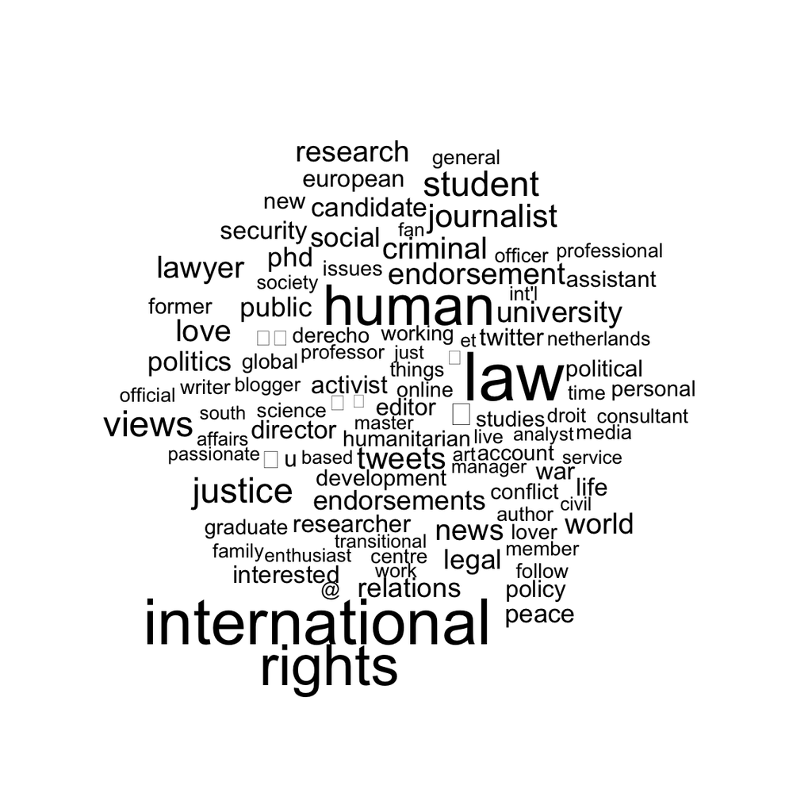

```r
wf <- tfidf(dfm)
# create wordcloud
par(mar=c(0,0,0,0))
plot(wf, rot.per=0, scale=c(3, .50), max.words=100)
```